# Predicting NJ Transit Train Delays During the COVID-19 Pandemic

Jiaxuan Lyu, Jiamin Tan

2020/12/15

### 1. Introduction

The COVID-19 pandemic brought lots of changes in people’s daily lives. COVID-19 is caused by a new coronavirus (called SARS-CoV-2) and can generate symptoms such as fever, cough, trouble breathing and etc. [(CDC, 2020)](https://www.cdc.gov/coronavirus/2019-ncov/symptoms-testing/symptoms.html). The World Health Organization suggests people to avoid COVID by wearing masks and keeping social distance [(WHO, 2020)](https://www.who.int/emergencies/diseases/novel-coronavirus-2019/advice-for-public). As the largest statewide public transit system in the US, New Jersey Transit is usually busy. When a major delay happened in [February](https://www.pix11.com/news/local-news/manhattan/nearly-3-hour-delays-massive-crowds-continue-at-penn-station) this year, severe crowding was observed in many of its stations. Under the pandemic, keeping a safe and healthy environment is always the first motive for public transportation services. In this project, we used a linear regression model to predict short-time delays of New Jersey Transit trains to help station staffs regulate passengers’ movements in stations to keep social distancing.  
The New Jersey Transit data we used is provided by Pranav Badami and mzhang13 on [Kaggle](https://www.kaggle.com/pranavbadami/nj-transit-amtrak-nec-performance). From the dataset, we selected data from March, April and May 2020 as the pandemic started in the US. After performing exploratory data analysis, we feature engineered both spatial and temporal features to fit our model. Moreover, we added weather data as features because weather condition like gust and visibility can be related to whether a train will delay or not.  
Our model is proved generalizable after running a k-fold cross validation - the model works well on predicting short-time delays (0~5 minutes) at all stations. Although it becomes less accurate when predicting longer-time delays, it does not affect the overall use case of our model. Under the pandemic, our model can provide accurate predictions of short-time delays requires station staffs to act earlier and give guidance for social distancing, in turn ensuring passengers’ safety at stations and on platforms.  
We also make a video that demonstrates our model’s use case. **The video could be viewed [here](https://www.youtube.com/watch?v=b_OVY2DLlv0&feature=youtu.be).**

### 2. Set Up

```r
#change the language to English
Sys.setenv(LANG = "en")

#change the system time
Sys.setlocale("LC_TIME", "English")

#avoid scientific notation
options(scipen = 999)
```

#### 2.1 Packages and Functions

##### 2.1.1 Load Packages

```r
#Load packages
library(tidyverse)
library(sf)
library(lubridate)
library(tigris)
library(tidycensus)
library(viridis)
library(riem)
library(gridExtra)
library(knitr)
library(kableExtra)
library(gganimate)
library(gifski)
library(caret)
library(ckanr)
library(kableExtra)
library(stargazer)
library(spdep)
library(FNN)
library(grid)
library(ggcorrplot)
library(jtools)
library(maptools)
library(broom)
library(dplyr)
library(nngeo)
library(geosphere)
library(wesanderson)
```

##### 2.1.2 Load Functions AND Palettes

```r
#Plot functions
plotTheme <- theme(
  plot.title =element_text(size=12),
  plot.subtitle = element_text(size=8),
  plot.caption = element_text(size = 6),
  axis.text.x = element_text(size = 10, angle = 45, hjust = 1),
  axis.text.y = element_text(size = 10),
  axis.title.y = element_text(size = 10),
  # Set the entire chart region to blank
  panel.background=element_blank(),
  plot.background=element_blank(),
  #panel.border=element_rect(colour="#F0F0F0"),
  # Format the grid
  panel.grid.major=element_line(colour="#D0D0D0",size=.2),
  axis.ticks=element_blank())

mapTheme <- function(base_size = 12) {
  theme(
    text = element_text( color = "black"),
    plot.title = element_text(size = 16,colour = "black"),
    plot.subtitle=element_text(face="italic"),
    plot.caption=element_text(hjust=0),
    axis.ticks = element_blank(),
    panel.background = element_blank(),axis.title = element_blank(),
    axis.text = element_blank(),
    axis.title.x = element_blank(),
    axis.title.y = element_blank(),
    panel.grid.minor = element_blank(),
    panel.border = element_rect(colour = "black", fill=NA, size=2),
    strip.text.x = element_text(size = 14))
}

# Quantile break functions
qBr <- function(df, variable, rnd) {
  if (missing(rnd)) {
    as.character(quantile(round(df[[variable]],0),
                          c(.01,.2,.4,.6,.8), na.rm=T))
  } else if (rnd == FALSE | rnd == F) {
    as.character(formatC(quantile(df[[variable]]), digits = 3),
                 c(.01,.2,.4,.6,.8), na.rm=T)
  }
}

q5 <- function(variable) {as.factor(ntile(variable, 5))}
```

```r
#color palette
palette1 <- c("#CCE5FF","#99CCFF","#66B2FF","#3399FF","#0066CC")
palette2 <- c("#CEFFF6","#9CFFEC","#33CCCC","#0FA8A8","#006666")
```

#### 2.2 Data

##### 2.2.1 Transit Data

```r
transit2003 <- read.csv("C:/资料/MUSA508/Final Project/2020_03.csv", stringsAsFactors=FALSE)
transit2004 <- read.csv("C:/资料/MUSA508/Final Project/2020_04.csv", stringsAsFactors=FALSE)
transit2005 <- read.csv("C:/资料/MUSA508/Final Project/2020_05.csv", stringsAsFactors=FALSE)

# get rid of NAs and focus on the Main/Bergen County Line
dat <- rbind(transit2003, transit2004, transit2005) %>%
  na.omit() %>%
  filter(line == "Main Line" )
```

```r
# interval 60
dat <- dat %>%
  mutate(scheduled_time = as_datetime(scheduled_time, tz = "America/New_York"),
         actual_time = as_datetime(actual_time, tz = "America/New_York")) %>%
  mutate(train_id = as.numeric(train_id), # conversion for specifying the direction
         direction = ifelse(train_id%%2 == 0, "toHoboken", "fromHoboken"), # specify the direction
         # floor hour and data using scheduled time
         interval60 = floor_date(ymd_hms(scheduled_time), unit = hours(x = 1)),
         # scheduled month, day, hour, minute
         month = month(interval60),
         day = day(interval60),
         hour = hour(interval60),
         minute = minute(scheduled_time),
         # scheduled time in decimal format
         time = hour + minute/60,
         # period of the day
         potd = ifelse(hour > 0 & hour < 7, "dawn",
                       ifelse(hour < 10, "morningRush",
                              ifelse(hour < 16, "dayTime",
                                     ifelse(hour < 21, "eveningRush", "nightTime")))),
         # day of the week
         dotw = lubridate::wday(interval60, label = TRUE),
         # whether "Mon/Fri", "Sat/Sun", or "Other" days
         dotw2 = ifelse(dotw == "Fri" | dotw == "Mon", "Mon/Fri", ifelse(dotw == "Sun" | dotw == "Sat", "Sat/Sun", "Other")),
         # actual month, day, hour, minute
         act_month = month(actual_time),
         act_day = day(actual_time),
         act_hour = hour(actual_time),
         act_minute = minute(actual_time),
         # actual time in decimal format
         act_time = act_hour + act_minute/60)


# create a unique identifier for each row with concatenated date and train_id
dat$unique <- paste(dat$date, dat$train_id , sep = " ")
```

##### 2.2.2 Transit Stop Spatial Data

The geospatial data of New Jersey transit stops are obtained from [NJGIN Open Data](https://njogis-newjersey.opendata.arcgis.com/datasets/railroad-stations-in-nj).

```r
# import stop location data and select related information
njTransStops <- read.csv("C:/资料/MUSA508/Final Project/Railroad_Stations_in_NJ.csv", stringsAsFactors=FALSE)

stops <- njTransStops %>%
  filter(RAIL_LINE == "Main/Bergen Line" |
           RAIL_LINE == "Port Jervis Line" |
           STATION == "Secaucus Junction Lower Level" |
           STATION == "Hoboken") %>%
  dplyr::select(STATION, LATITUDE, LONGITUDE)

# renaming to unify the station names from different data set
stops[3,1] <- "Ramsey Main St"
stops[8,1] <- "Glen Rock Main Line"
stops[24,1] <- "Middletown NY"
stops[30,1] <- "Ramsey Route 17"
stops[31,1] <- "Secaucus Lower Lvl"
```

```r
#get unique stops in Main Line
Mstops <- as.data.frame(unique(dat$to))

#merge to get coordinates
Mstops <- merge(Mstops, stops, by.x="unique(dat$to)", by.y="STATION")

#change column names
colnames(Mstops)[1] <- "STATION"
#change to sf
Mstops.sf <- Mstops %>%
  st_as_sf(coords = c("LONGITUDE", "LATITUDE"), crs = 4326, agr = "constant") %>%
  st_transform('ESRI:102711')
```

##### 2.2.3 Census Data

The US Census Data is also used to extract census blocks surrounding the transit.

```r
# get census data from NJ and NY in county level
acs5NJ <- get_acs(geography = "county",
                  state = "NJ",
                  variables = c("B01003_001", "B08006_012"),
                  year = 2018,
                  survey = "acs5",
                  geometry = TRUE,
                  output = "wide") %>%
  dplyr::select(-B01003_001M, -B08006_012M) %>%
  st_transform('ESRI:102711') %>% ## 102711
  rename(TotalPop = B01003_001E,
         RailPop = B08006_012E)

acs5NY <- get_acs(geography = "county",
                  state = "NY",
                  variables = c("B01003_001", "B08006_012"),
                  year = 2018,
                  survey = "acs5",
                  geometry = TRUE,
                  output = "wide") %>%
  dplyr::select(-B01003_001M, -B08006_012M) %>%
  st_transform('ESRI:102711') %>% ## 102711
  rename(TotalPop = B01003_001E,
         RailPop = B08006_012E)

# combine the data from the two states and select geometries intersect with stations
acs5 <- rbind(acs5NJ, acs5NY)
acs5 <- acs5[Mstops.sf, ]
```

##### 2.2.4 Weather Data

Due to spatial autocorrelation and data availability, we applied the weather data in New York City to all the stations on the line. The weather data in NYC are extractced by using `riem` package in R.

```r
# get weather data
weatherNY <- riem_measures(station = "NYC", date_start = "2020-03-01", date_end = "2020-05-17") %>%
  dplyr::select(valid, drct, sknt, p01i, vsby, gust)%>%
  replace(is.na(.), 0) %>%
  mutate(interval60 = ymd_h(substr(valid,1,13))) %>%
  mutate(week = week(interval60),
         dotw = lubridate::wday(interval60, label=TRUE)) %>%
  group_by(interval60) %>%
  summarize(Wind_Drect = max(drct),
            Precipitation = sum(p01i),
            Wind_Speed = max(sknt),
            Visibility = max(vsby),
            Gust = max(gust))
```

### 3. Exploratory Data Analysis

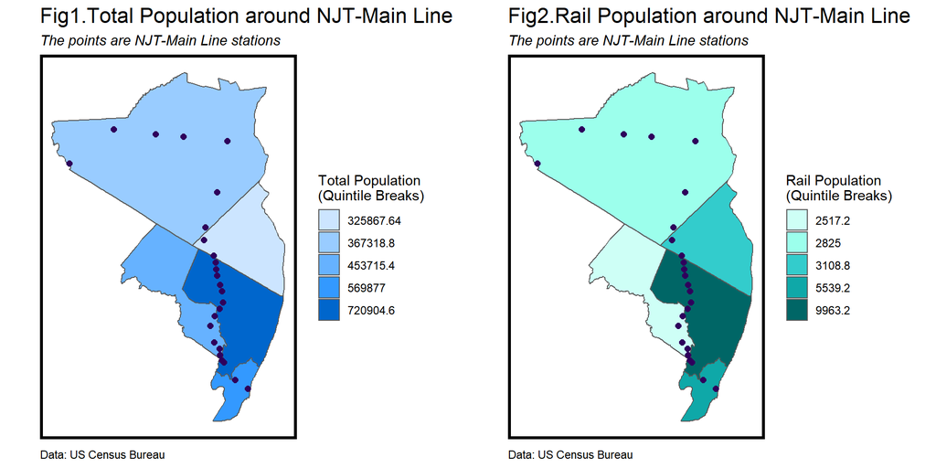

```r
#Visualization Transit Stops
grid.arrange(
ggplot(data=acs5)+
  geom_sf(aes(fill=q5(TotalPop))) +
  geom_sf(data=Mstops.sf, color="#2E005C", size=2) +
  scale_fill_manual(values = palette1,
                    labels = qBr(acs5, "TotalPop"),
                    name = "Total Population\n(Quintile Breaks)")+
  labs(title = "Fig1.Total Population around NJT-Main Line",
       subtitle = "The points are NJT-Main Line stations",
       caption = "Data: US Census Bureau")+
  theme(plot.title = element_text(size=12)) +
  mapTheme(),
ggplot(data=acs5)+
  geom_sf(aes(fill=q5(RailPop))) +
  geom_sf(data=Mstops.sf, color="#2E005C", size=2) +
  scale_fill_manual(values = palette2,
                    labels = qBr(acs5, "RailPop"),
                    name = "Rail Population\n(Quintile Breaks)")+
  labs(title = "Fig2.Rail Population around NJT-Main Line",
       subtitle = "The points are NJT-Main Line stations",
       caption = "Data: US Census Bureau")+
  theme(plot.title = element_text(size=12))+
  mapTheme(), ncol=2)
```

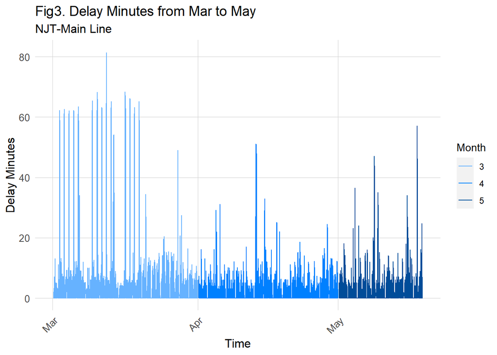

```r
#overall delay minutes by month
ggplot()+
  geom_line(data=dat, aes(x=interval60, y=delay_minutes, color=factor(month)))+
  scale_colour_manual(name="Month", values = c("#66B2FF", "#0080FF", "#004C99")) +
  labs(title="Fig3. Delay Minutes from Mar to May",
       subtitle="NJT-Main Line",
       x="Time",
       y="Delay Minutes")+
  plotTheme +
  theme(plot.title = element_text(size=14),
        plot.subtitle = element_text(size=12),
        axis.title.x = element_text(size = 12),
        axis.title.y = element_text(size = 12))
```

Figure 3 shows the overall delay minutes by time. Compared to April and May, March has much longer delay minutes.

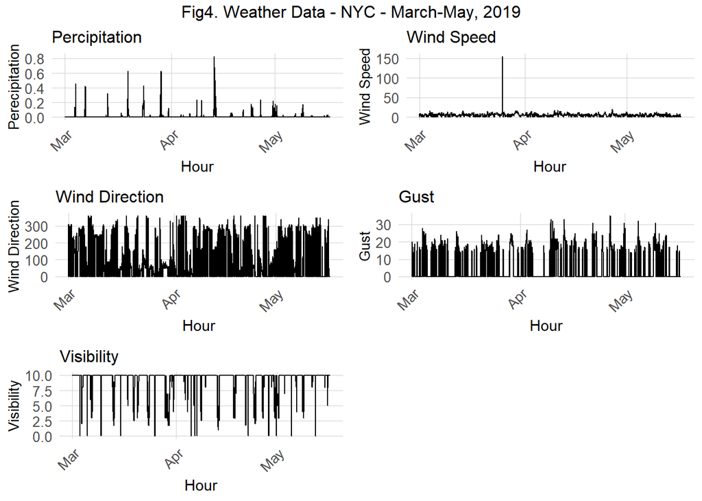

```r
#Weather Data
# plot the whether
grid.arrange(
  ggplot(weatherNY, aes(interval60, Precipitation)) + geom_line() +
    labs(title="Percipitation", x="Hour", y="Perecipitation") + plotTheme,
  ggplot(weatherNY, aes(interval60, Wind_Speed)) + geom_line() +
    labs(title="Wind Speed", x="Hour", y="Wind Speed") + plotTheme,
  ggplot(weatherNY, aes(interval60, Wind_Drect)) + geom_line() +
    labs(title="Wind Direction", x="Hour", y="Wind Direction") + plotTheme,
  ggplot(weatherNY, aes(interval60, Gust)) + geom_line()+
    labs(title="Gust", x="Hour", y="Gust") + plotTheme,
  ggplot(weatherNY, aes(interval60, Visibility)) + geom_line()+
    labs(title="Visibility", x="Hour", y="Visibility") + plotTheme,
  top="Fig4. Weather Data - NYC - March-May, 2019")
```

Figure 4 shows the precipitation, wind speed, wind direction, gust and visibility in NYC through March, April and May. Compared Figure 4 with Figure 3, there are correlations to some extent. For instance, there are more severe precipitation events in March than in April and May, and March had longer delayed time than April and May did. The higher frequencies of some weathers might cause longer transit delay minutes.

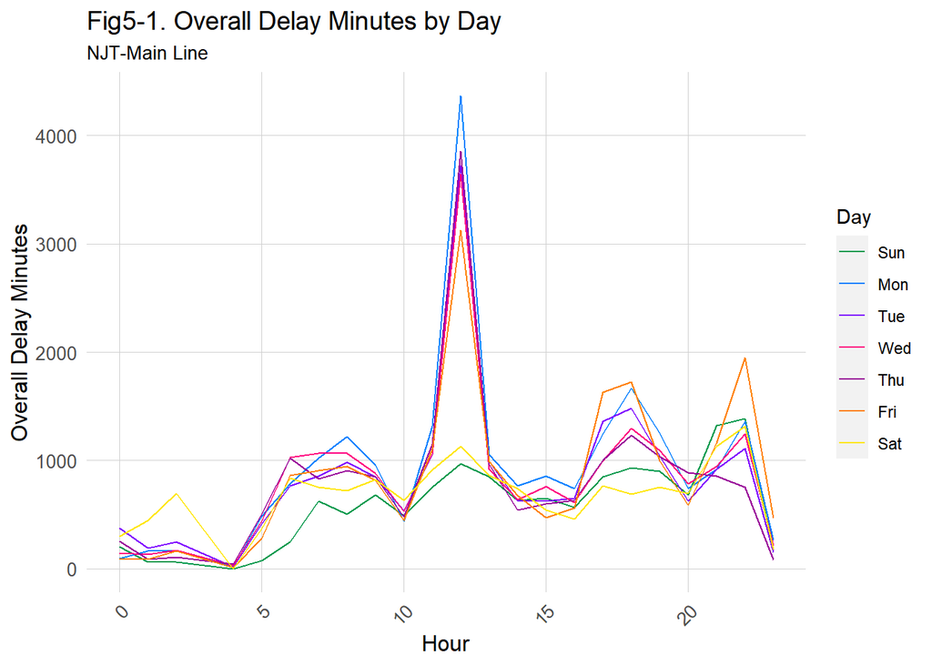

```r
#overall delay minutes by dotw(Weekday/Weekend)
dat %>%
  select(hour, delay_minutes, dotw) %>%
  group_by(hour, dotw) %>%
  summarise(sum_delay = sum(delay_minutes)) %>%
  ggplot(aes(x = hour, y = sum_delay, color = dotw)) +
  geom_line() +
  scale_colour_manual(name="Day",
                      values = c("#00994C", "#0080FF","#7F00FF",
                                 "#FF007F", "#990099", "#FF8000", "#FFE600")) +
  labs(title="Fig5-1. Overall Delay Minutes by Day",
       subtitle="NJT-Main Line",
       x="Hour",
       y="Overall Delay Minutes",
       color="Day") +
  plotTheme +
  theme(plot.title = element_text(size=14),
        axis.title.x = element_text(size = 12),
        axis.title.y = element_text(size = 12),
        plot.subtitle = element_text(size = 10))
```

Figure 5-1 shows overall delay minutes in one day. Different colors indicate different day of week. From the figure, we could see that Saturday and Sunday have lower overall delay minutes, compared to other weekdays do.

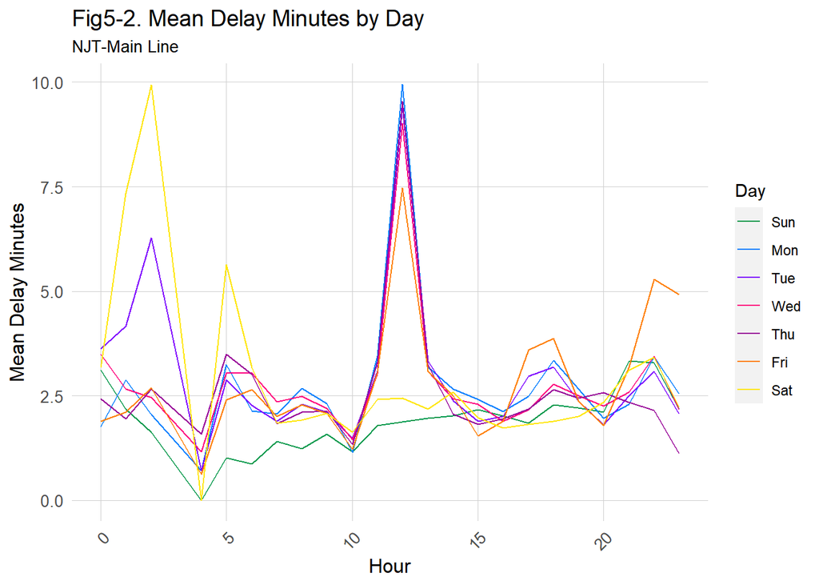

```r
#mean delay by day

dat %>%
  select(hour, delay_minutes, dotw) %>%
  group_by(hour, dotw) %>%
  summarise(mean_delay = mean(delay_minutes)) %>%
  ggplot(aes(x = hour, y = mean_delay, color = dotw)) +
  geom_line() +
  scale_colour_manual(name="Day",
                      values = c("#00994C", "#0080FF","#7F00FF",
                                 "#FF007F", "#990099", "#FF8000", "#FFE600")) +
  labs(title="Fig5-2. Mean Delay Minutes by Day",
       subtitle="NJT-Main Line",
       x="Hour",
       y="Mean Delay Minutes",
       color="Day") +
  plotTheme +
  theme(plot.title = element_text(size=14),
        axis.title.x = element_text(size = 12),
        axis.title.y = element_text(size = 12),
        plot.subtitle = element_text(size = 10))
```

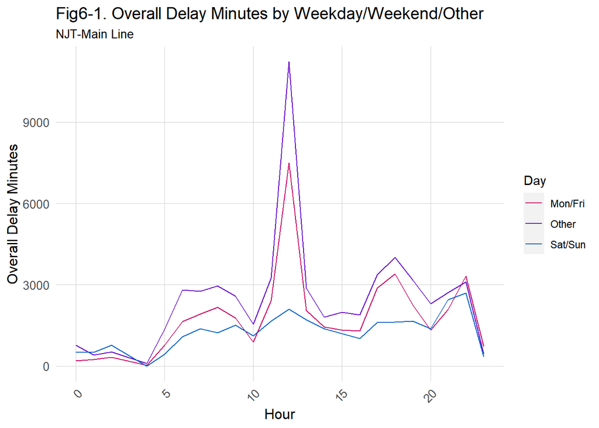

```r
dat %>%
  select(dotw2, hour, delay_minutes) %>%
  group_by (dotw2, hour) %>%
  summarise(sum_delay = sum(delay_minutes)) %>%
  ggplot(aes(x=hour, y=sum_delay, color=dotw2)) +
  geom_line() +
  scale_colour_manual(name="Day", values = c("#CC0066", "#6600CC", "#0066CC")) +
  labs(title="Fig6-1. Overall Delay Minutes by Weekday/Weekend/Other",
       subtitle="NJT-Main Line",
       x="Hour",
       y="Overall Delay Minutes")+
  plotTheme+
  theme(plot.title = element_text(size=14),
        axis.title.x = element_text(size = 12),
        axis.title.y = element_text(size = 12),
        plot.subtitle = element_text(size = 10))
```

To better visualize the potential differences among weekends and weekdays, we grouped the transit as Mon/Fri, Sat/Sun and Other. From Figure 6, we could see that weekdays still have a peak at around noon, and the Sat/Sun group has a different pattern.

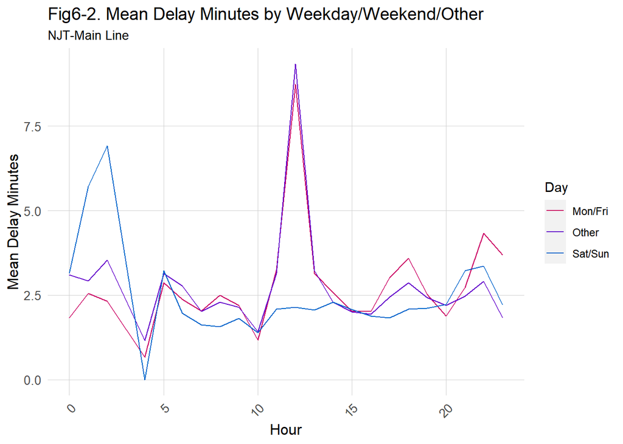

```r
dat %>%
  select(dotw2, hour, delay_minutes) %>%
  group_by (dotw2, hour) %>%
  summarise(mean_delay = mean(delay_minutes)) %>%
  ggplot(aes(x=hour, y=mean_delay, color=dotw2)) +
  geom_line() +
  scale_colour_manual(name="Day", values = c("#CC0066", "#6600CC", "#0066CC")) +
  labs(title="Fig6-2. Mean Delay Minutes by Weekday/Weekend/Other",
       subtitle="NJT-Main Line",
       x="Hour",
       y="Mean Delay Minutes")+
  plotTheme+
  theme(plot.title = element_text(size=14),
        axis.title.x = element_text(size = 12),
        axis.title.y = element_text(size = 12),
        plot.subtitle = element_text(size = 10))
```

Figure 6-2 shows similar patterns as Figure 5-2. Transit at weekend differences to Mon/Fri group and Other group among the early morning time.  
Overall, the created group helped us see the differences among weekends and weekdays, but the differences within weekdays are not clear.

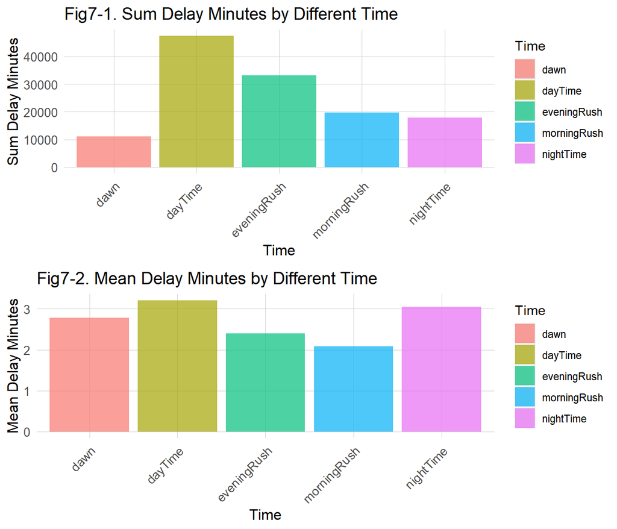

```r
grid.arrange(
  dat %>%
  select(potd, delay_minutes) %>%
  group_by(potd) %>%
  summarise(sum_delay = sum(delay_minutes)) %>%
  ggplot(aes(x = potd, y=sum_delay, fill = potd)) +
  geom_bar(stat="identity", alpha=0.7) +
  labs(x = "Time",
       y = "Sum Delay Minutes",
       title = "Fig7-1. Sum Delay Minutes by Different Time",
       fill = "Time") +
  plotTheme +
  theme(plot.title = element_text(size=14),
        axis.title.x = element_text(size = 12),
        axis.title.y = element_text(size = 12),
        plot.subtitle = element_text(size=10)),
  dat %>%
    select(potd, delay_minutes) %>%
    group_by(potd) %>%
    summarise(mean_delay = mean(delay_minutes)) %>%
    ggplot(aes(x = potd, y=mean_delay, fill = potd)) +
    geom_bar(stat="identity", alpha=0.7) +
    labs(x = "Time",
       y = "Mean Delay Minutes",
       title = "Fig7-2. Mean Delay Minutes by Different Time",
       fill = "Time") +
    plotTheme +
    theme(plot.title = element_text(size=14),
        axis.title.x = element_text(size = 12),
        axis.title.y = element_text(size = 12),
        plot.subtitle = element_text(size=10))
)
```

The time group is created when we extracting related time information by using `lubricate` package.  
From Figure 7-1, there is a large difference among dawn and dayTime, but their mean values are similar based on Figure 7-2. The high mean-value of dawn group might be caused by extreme values. Also, this pattern here is similar to Figure 6-1 and Figure 6-2.

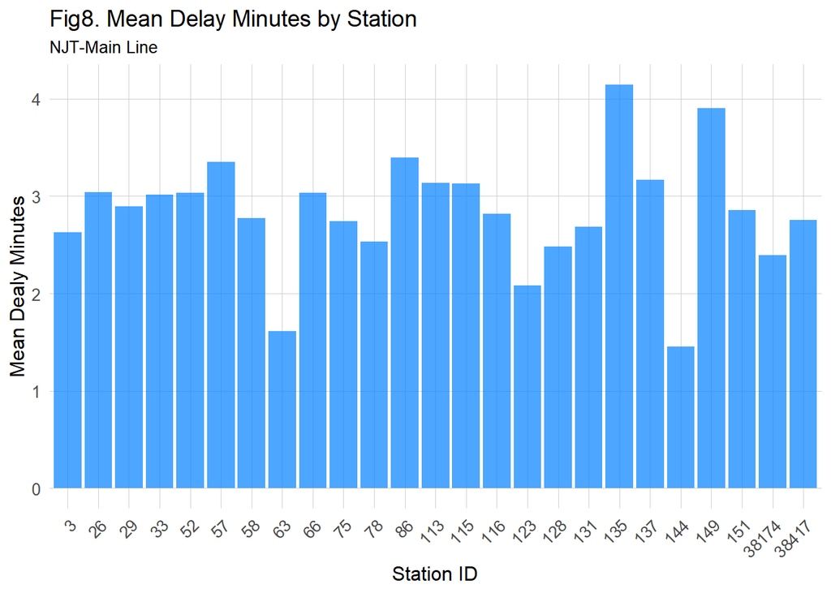

```r
#overall delay by station
dat %>%
  select(to_id, delay_minutes) %>%
  group_by (to_id) %>%
  summarise(mean_delay = mean(delay_minutes)) %>%
  ggplot(aes(x=factor(to_id), y=mean_delay)) +
  geom_bar(stat="identity", fill="#0080FF", alpha=0.7) +
  labs(x="Station ID",
       y="Mean Dealy Minutes",
       title="Fig8. Mean Delay Minutes by Station",
       subtitle="NJT-Main Line")+
  plotTheme+
    theme(plot.title = element_text(size=14),
          axis.title.x = element_text(size = 12),
          axis.title.y = element_text(size = 12),
          plot.subtitle = element_text(size=10))
```

Figure 8 illustrates mean delay minutes by stations. Station 135, which is station **Salisbury Mills-Cornwall**, has the highest mean delay_minutes. Station 144, which is station **Suffern** has the lowest mean delay_minutes.

```r
dat$train_id <- as.character(dat$train_id)
```

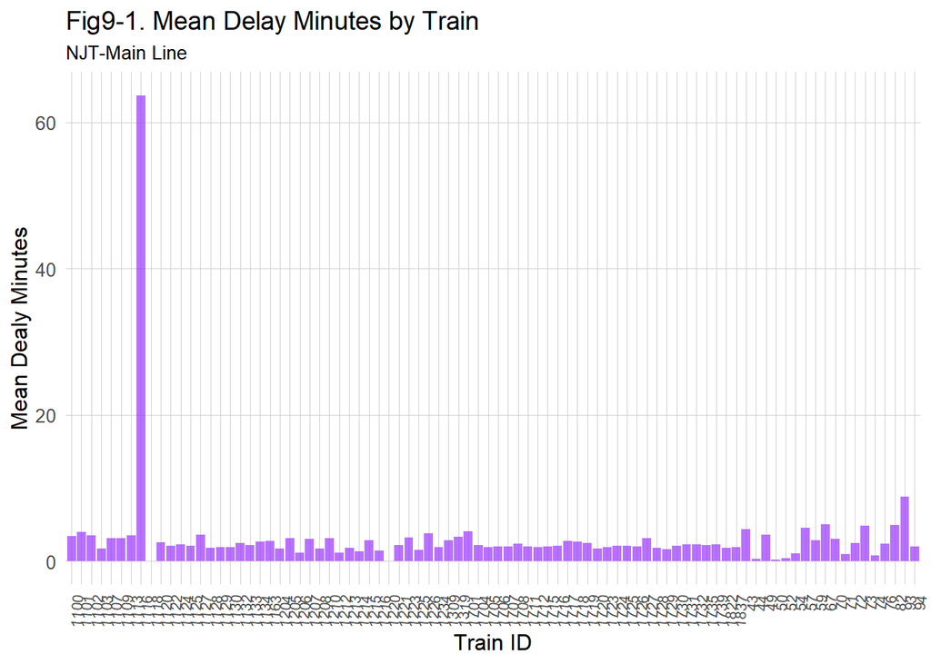

```r
#overall delay by train
dat %>%
  select(train_id, delay_minutes) %>%
  group_by(train_id) %>%
  summarise(mean_delay = mean(delay_minutes)) %>%
  ggplot(aes(x=train_id, y=mean_delay)) +
  geom_bar(stat="identity", fill="#9933FF", alpha=0.7) +
  labs(x="Train ID",
       y="Mean Dealy Minutes",
       title="Fig9-1. Mean Delay Minutes by Train",
       subtitle="NJT-Main Line")+
  plotTheme+
  theme(axis.title.x = element_text(size = 12),
        axis.title.y = element_text(size = 12),
        plot.subtitle = element_text(size=10),
        axis.text.x = element_text(size = 8, angle = 85, hjust = 1),
        plot.title = element_text(size=14))
```

Figure 9-1 shows the mean delay minutes by train. From the graph, we could see that **Train ID 1116** has the highest mean delay.

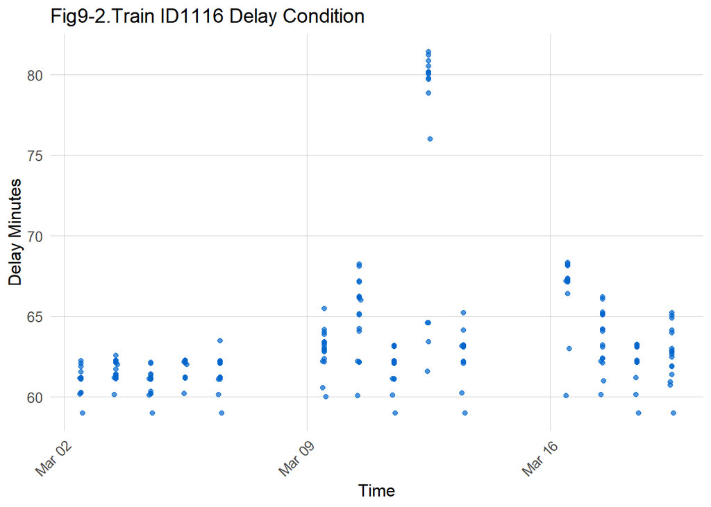

```r
dat %>%
  select(interval60, from, to, train_id, delay_minutes) %>%
  filter(train_id == "1116") %>%
  ggplot(aes(x=interval60, y=delay_minutes)) +
  geom_point(color = "#0066CC", alpha=0.7) +
  labs(x = "Time",
       y = "Delay Minutes",
       title = "Fig9-2.Train ID1116 Delay Condition") +
  plotTheme +
  theme(axis.title.x = element_text(size = 12),
        axis.title.y = element_text(size = 12),
        plot.title = element_text(size=14))
```

Figure 9-2 visualizes the delay condition of Train 1116. This train only has recorded delay data in March from the chosen time period. The website [njtranshit.com](https://njtranshit.com/train/1116) documented a delay reason for March 12th, which is police assistance due to unruly customer. But other delay reasons are not documented.

### 4. Feature Engineering

#### 4.1 Delay for Previous station and Next Station at Previous Hour

```r
#1.get the total delay of previous hour
# get the total delay of each "'from' 'to'" pair within the 1 hour period of its floor hour
sumDelayBtwStops <- dat %>%
  group_by(from_id, to_id, direction, month, day, hour) %>%
  summarise(delay1 = sum(delay_minutes)) %>%
  as.data.frame()

# create a new column for later use
sumDelayBtwStops$preDelay <- 0

# for each "'from' 'to'" pair in its own 1-hour period floor hour,
# get the total delay of the previous 1-hour period
for (i in 1:(nrow(sumDelayBtwStops) - 1)){
  if(sumDelayBtwStops[i+1, 4] == sumDelayBtwStops[i, 4] &
     sumDelayBtwStops[i+1, 5] == sumDelayBtwStops[i, 5] &
     sumDelayBtwStops[i+1, 6] == (sumDelayBtwStops[i, 6] + 1)){
    sumDelayBtwStops[i+1, 8] = sumDelayBtwStops[i, 7]
  }
}

# merge to get the total delay of the previous 1-hour period of each "'from' 'to'" pair
dat2 <- merge(dat, sumDelayBtwStops)
# assigning an ID to each row for reference use
dat$ID <- 1:nrow(dat)
# following 3 lines just to restore the merged data into the original order for later use
dat3 <- merge(dat, dat2)
dat4 <- dat3[order(dat3$ID),]
rownames(dat4) <- 1:nrow(dat4)


# mutating two columns of the total delay happened in the 1-hour floor hour in either
# previous "'from' 'to'" pairs or next "'from' 'to'" pairs
dat5 <- dat4 %>%
  dplyr::select(train_id, month, day, preDelay) %>%
  group_by(train_id, month, day) %>%
  # shift the column down by 1 cell to get delay of the previous "'from' 'to'" delay
  mutate(preDelay = dplyr::lag(preDelay),
         # shift the column up by 1 cell to get delay of the next "'from' 'to'" delay
         nextDelay = dplyr::lead(preDelay))


# merge the result to the original data
dat$preDelay <- dat5$preDelay
dat$nextDelay <- dat5$nextDelay
```

Other than the features that we made based on time, we aim to engineer a feature that demonstrates spatial influence and time influence. To illustrate, the transit line works as a network, and the delay minutes between stops are correlated. If we are at the second stop, the delays at the first stop (previous stop) and delay at the third stop (next stop) will influence the delay at current stop. Moreover, if there were severe delay at the previous hour, there might be delay at current.  
Based on these considerations, we made two features. The first feature, **preDelay** is the *summarized delay in previous one hour at previous station*, and the second feature, **nextDelay** is the *summarized delay in previous one hour at next station*.

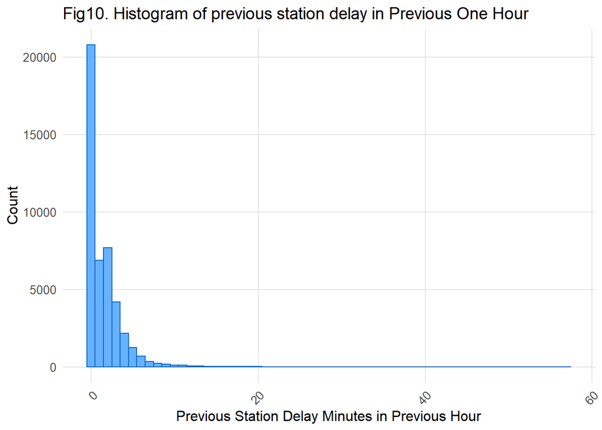

```r
#predelay
ggplot(dat, aes(x=preDelay))+
  geom_histogram(binwidth = 1, fill="#66B2FF", color="#0066CC") +
  labs(x = "Previous Station Delay Minutes in Previous Hour",
       y = "Count",
       title = "Fig10. Histogram of previous station delay in Previous One Hour") +
  plotTheme +
  theme(axis.title.x = element_text(size = 12),
        axis.title.y = element_text(size = 12),
        plot.title = element_text(size=14))
```

Figure 10 shows the histogram of preDelay feature. There is a spike at 0, and the majority of delays are less than 10 minutes.

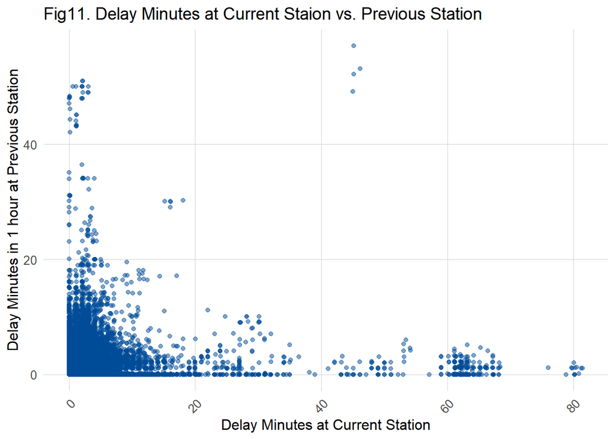

```r
ggplot(dat, aes(x=delay_minutes, y=preDelay))+
  geom_point(color="#004C99", alpha=0.5) +
  labs(x = "Delay Minutes at Current Station",
       y = "Delay Minutes in 1 hour at Previous Station",
       title= "Fig11. Delay Minutes at Current Staion vs. Previous Station") +
  plotTheme +
  theme(axis.title.x = element_text(size = 12),
        axis.title.y = element_text(size = 12),
        plot.title = element_text(size=14))
```

Figure 11 shows the correlation between the real-time delay minutes and the engineered feature preDelay. From the graph, there is no clear linear pattern. But is seems stations which have long real-time delay minutes tend to have shorter delay minutes at previous station at previous hour.

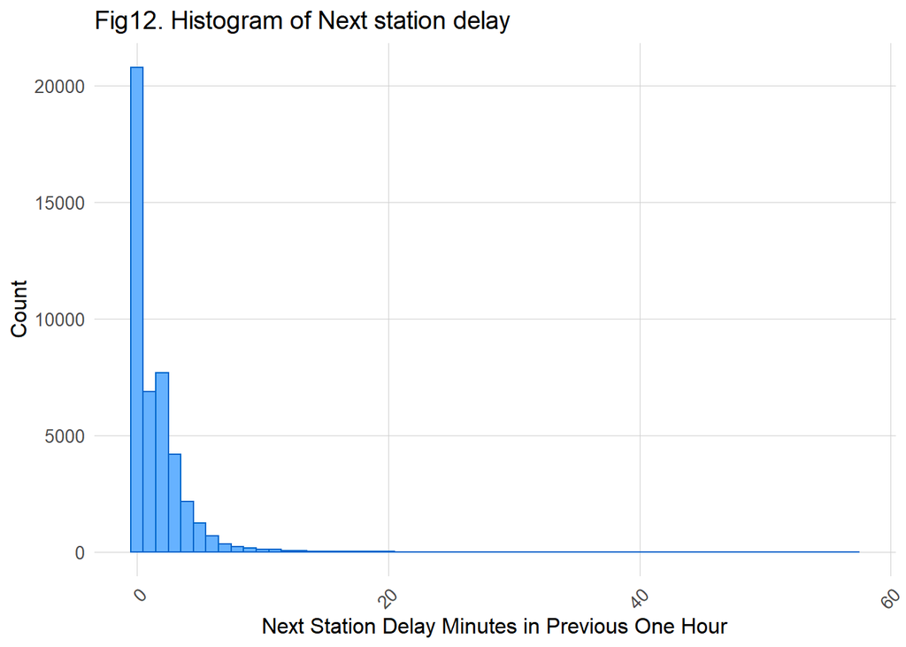

```r
ggplot(dat, aes(x=nextDelay))+
  geom_histogram(binwidth = 1, fill="#66B2FF", color="#0066CC") +
  labs(x = "Next Station Delay Minutes in Previous One Hour",
       y = "Count",
       title = "Fig12. Histogram of Next station delay") +
  plotTheme +
  theme(axis.title.x = element_text(size = 12),
        axis.title.y = element_text(size = 12),
        plot.title = element_text(size = 14))
```

Figure 12 shows the histogram of previous 1-hour delay at next station. Similar to Figure 10, the majority of delay minutes are less than 10 minutes.

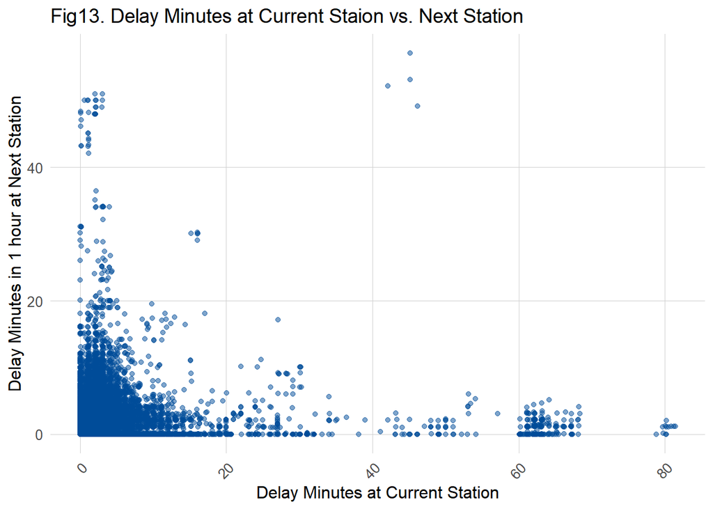

```r
ggplot(dat, aes(x=delay_minutes, y=nextDelay))+
  geom_point(color="#004C99", alpha=0.5) +
  labs(x = "Delay Minutes at Current Station",
       y = "Delay Minutes in 1 hour at Next Station",
       title= "Fig13. Delay Minutes at Current Staion vs. Next Station") +
  plotTheme +
  theme(axis.title.x = element_text(size = 12),
        axis.title.y = element_text(size = 12),
        plot.title = element_text(size = 14))
```

Figure 13 shows the correlation between feature nextDealy and real-time delay minutes. There is no clear linear relationship. However, the stations which have extreme delay minutes tend to have shorter delay minutes at the next station.

#### 4.2 Cumulative Dealy

```r
# create a column of cumulative delay at the station
dat$cumulative_delay <- ave(dat$delay_minutes, dat$unique, FUN = cumsum)
```

We also made a feature that summarize cumulative delay minutes for one train in one day (**cumulative delay**). When the train is in service on the day we want to predict, we are not able to summarize cumulative delay on that day because the delay has not happen yet. Therefore, we will continue engineering this feature at the later part. Same to the nextDelay feature.  
But in order to have a sense about how the feature looks like, we make Figure 14. Figure 14 shows there is a linear relationship between the cumulative delay feature and real-time delay minutes. We can see that they are positively related.

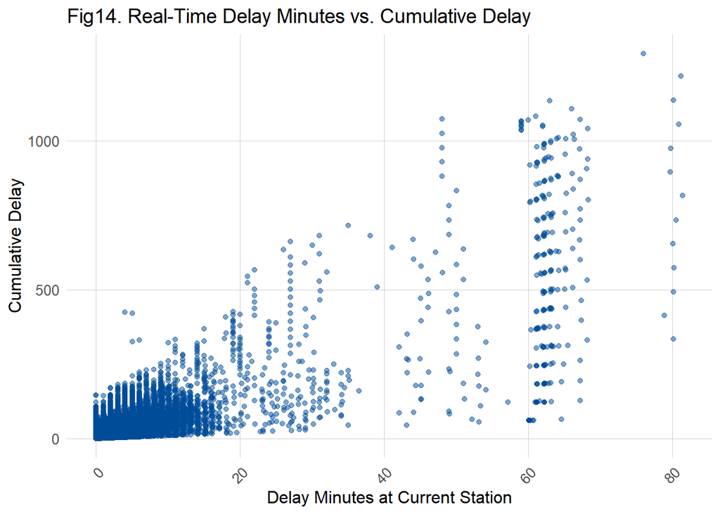

```r
#vis
ggplot(dat, aes(x=delay_minutes, y=cumulative_delay))+
  geom_point(color="#004C99", alpha=0.5) +
  labs(x = "Delay Minutes at Current Station",
       y = "Cumulative Delay",
       title= "Fig14. Real-Time Delay Minutes vs. Cumulative Delay") +
  plotTheme +
  theme(axis.title.x = element_text(size = 12),
        axis.title.y = element_text(size = 12),
        plot.title = element_text(size = 14))
```

#### 4.3 Cumulative Delay Over Space (5 stops away: Previous)

```r
# cumulative delay 5 stops away on the day (previous 5 stops)
dat <- dat %>%
  group_by(unique) %>%
  mutate(cumulative_delay_5stopsAway = dplyr::lag(cumulative_delay, n = 5))
```

As mentioned at earlier part, we continue engineering our **cumulative delay** feature. Under the real world condition, we are not able to get cumulative delay for the train at current station, but we are able to obtain cumulative delay for the train at previous five stops away. We believe there will be enough time for the station staffs to prepare guidance plans if the train is currently five stops away.

```r
# replace all the NAs with 0 min delays
# since NAs were generated with no previous/following "'from' 'to'" pairs
dat[is.na(dat)] <- 0
```

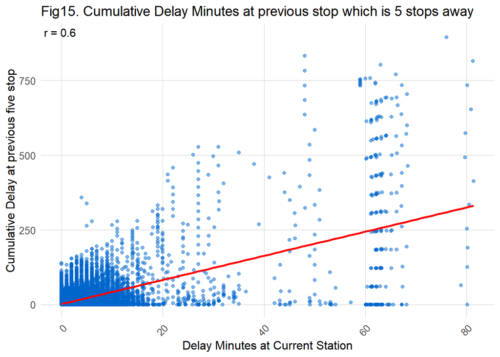

```r
#visualization
pre5cor <- as.data.frame(cor(dat$delay_minutes, dat$cumulative_delay_5stopsAway))

ggplot(dat, aes(x=delay_minutes, y=cumulative_delay_5stopsAway))+
  geom_point(color="#0066cc", alpha=0.5) +
  geom_smooth(method='lm', formula= y~x, color="red")+
  geom_text(data = pre5cor, aes(label = paste("r =", round(pre5cor, 2))),
            x=-Inf, y=Inf, vjust = 1.5, hjust = -.1, size=4) +
  labs(x = "Delay Minutes at Current Station",
       y = "Cumulative Delay at previous five stop",
       title= "Fig15. Cumulative Delay Minutes at previous stop which is 5 stops away") +
  plotTheme +
  theme(axis.title.x = element_text(size = 12),
        axis.title.y = element_text(size = 12),
        plot.title = element_text(size = 14))
```

Figure 15 shows that there is a linear relationship between the cumulative delay at previous 5 stops and the real-time delay minutes. They are positively related, and have a r of 0.6.

#### 4.4 Distance Between Two Stops and Speed

```r
# get the time difference
dat <- dat %>%
  group_by(unique) %>%
  # between the scheduled departure time
  mutate(timeDiff = time - lag(time, default = time[1]),
         # between the actual departure time
         act_timeDiff = act_time - lag(act_time, default = act_time[1]))
# deal with negative value caused by crossing midnight
dat$timeDiff[dat$timeDiff<0] <- dat$timeDiff[dat$timeDiff<0] + 24
dat$act_timeDiff[dat$act_timeDiff<0] <- dat$act_timeDiff[dat$act_timeDiff<0] + 24
```

```r
# get unique "'from' 'to'" pairs
dat6 <- dat %>%
  group_by(from, to) %>%
  count() %>%
  dplyr::select(-n)

# get the from and to coordinates for the unique "'from' 'to'" pairs
colnames(stops) <- c("from", "from_lat", "from_lon")
dat6 <- merge(dat6, stops, by = "from", all.x = TRUE)
colnames(stops) <- c("to", "to_lat", "to_lon")
dat6 <- merge(dat6, stops, by = "to", all.x = TRUE)

dat6 <- dat6[ , c(2,1,3,4,5,6)]

# calculate the (great circle/Euclidean (since using coordinates in a small scale)) distance
# of each unique "'from' 'to'" pair
for (i in 1:nrow(dat6)){
  dat6$dist[i] <- distm(c(dat6[i, 4], dat6[i, 3]), c(dat6[i, 6], dat6[i, 5]), fun = distHaversine)
}

# merge the distance to the original data
dat <- merge(dat, dat6, by = c("from", "to"))

# get the scheduled and actual speed between each "'from' 'to'" pair
dat$avgSpeed <- dat$dist/(dat$timeDiff + 0.00001) # cannot divided by 0
dat$act_avgSpeed <- dat$dist/(dat$act_timeDiff + 0.00001)
```

Furthermore, we calculated the distance between two stops and the time differences for the train to pass to stops. Then we use the distances and time differences to calculate the scheduled speed and actual speed between each two-stop sequence.

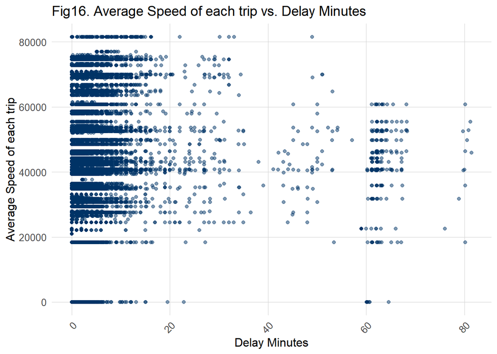

```r
ggplot(data=dat, aes(x=delay_minutes, y=avgSpeed))+
  geom_point(color="#003366", alpha=0.5) +
  labs(x = "Delay Minutes",
       y = "Average Speed of each trip",
       title = "Fig16. Average Speed of each trip vs. Delay Minutes")+
  plotTheme+
  theme(axis.title.x = element_text(size = 12),
        axis.title.y = element_text(size = 12),
        plot.title =  element_text(size = 14))
```

Figure 16 shows the relationship between scheduled average speed for each trip and the real-time delay minutes. Based on the figure, there is no clear pattern.

#### 4.5 Add Weather Data As Features

```r
# merge weather data to the original data
dat <- merge(dat, weatherNY)
```

Based on Figure 3 and Figure 4, we hold the idea that the weather data are correlated with transit delays. So we add the weather data as our features.

#### 4.6 Time Lag on Previous Features (7 days before)

```r
dat_lag7day <- dat %>%
  mutate(lag_date = as.Date(date) + 7,
         unique = paste(lag_date, train_id , sep = " ")) %>%
  dplyr::select(unique, from, to,
                date, delay_minutes, act_timeDiff, preDelay, nextDelay,
                cumulative_delay, act_avgSpeed)

# rename it with a "sd_" at the beginning indicating date seven days ago
colnames(dat_lag7day)[4:10] <- paste("sd_", colnames(dat_lag7day)[4:10], sep = "")

# select current day variables which will be used in the model
dat_new <- dat %>%
  dplyr::select(unique, from, to, month, train_id,
                stop_sequence, scheduled_time, actual_time, status, line, type, ID, date,
                potd, dotw2, delay_minutes, time, avgSpeed, cumulative_delay_5stopsAway, Precipitation, Wind_Speed, Wind_Drect, Gust, Visibility
                )

# rename it with a "cd_" at the beginning indicating current date
# except for "unique", "from", and "to" because they are keys for merging later
colnames(dat_new)[14:24] <- paste("cd_", colnames(dat_new)[14:24], sep = "")


# merge
dat_new <- merge(dat_new, dat_lag7day, by = c("unique", "from", "to"), all.y = TRUE)

# remove NAs created from 7 days more from the latest date
dat_new <- na.omit(dat_new)
```

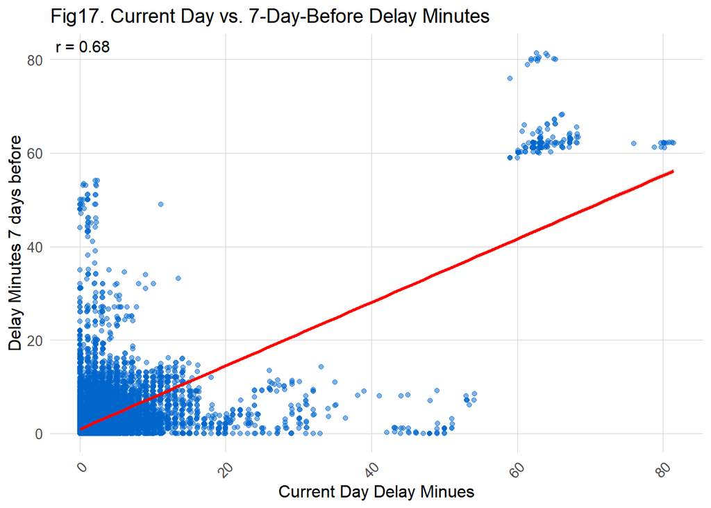

```r
#sd_delay_minutes
sdcd_cor <- as.data.frame(cor(dat_new$cd_delay_minutes, dat_new$sd_delay_minutes))


ggplot(dat_new, aes(x=cd_delay_minutes, y=sd_delay_minutes))+
  geom_point(color="#0066cc", alpha=0.5) +
  geom_smooth(method='lm', formula= y~x, color="red")+
  geom_text(data = sdcd_cor, aes(label = paste("r =", round(sdcd_cor, 2))),
            x=-Inf, y=Inf, vjust = 1.5, hjust = -.1, size=4) +
  labs(x = "Current Day Delay Minues",
       y = "Delay Minutes 7 days before",
       title= "Fig17. Current Day vs. 7-Day-Before Delay Minutes") +
  plotTheme +
  theme(axis.title.x = element_text(size = 12),
        axis.title.y = element_text(size = 12),
        plot.title =  element_text(size = 14))
```

Finally, we made a 7-day time lag for previous features. There are two reasons for doing this. First, based on Figure 3, there are cyclical variations among delay minutes, and trains will most likely to repeat their traveling behavior in a weekly basis. Second, as mentioned when calculating the cumulative delay minutes, there is no way to know the cumulative delay of the entire trip on the day that we are predicting. Therefore we decide to make a 7-day lag for delay minutes, time difference, summarized previous 1-hour delay at previous station, summarized previous 1-hour delay at next station, cumulative delay and actual average speed.  
From Figure 17, we could see that these two features are positively correlated, and r is 0.68.

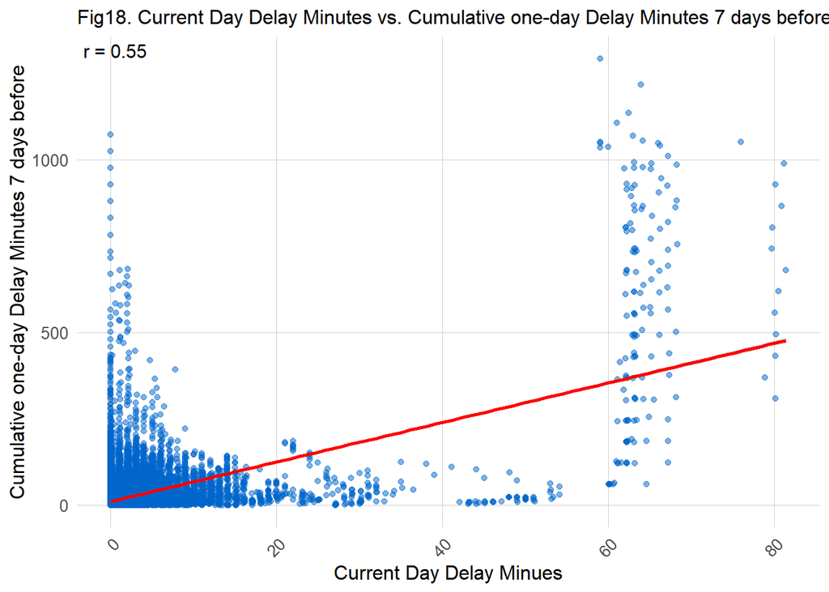

```r
#sd_cumulative_delay (cumulative delay minutes in one day)

cdsdcum <- as.data.frame(cor(dat_new$cd_delay_minutes, dat_new$sd_cumulative_delay))

ggplot(dat_new, aes(x=cd_delay_minutes, y=sd_cumulative_delay))+
  geom_point(color="#0066cc", alpha=0.5) +
  geom_smooth(method='lm', formula= y~x, color="red")+
  geom_text(data = cdsdcum, aes(label = paste("r =", round(cdsdcum, 2))),
            x=-Inf, y=Inf, vjust = 1.5, hjust = -.1, size=4) +
  labs(x = "Current Day Delay Minues",
       y = "Cumulative one-day Delay Minutes 7 days before",
       title= "Fig18. Current Day Delay Minutes vs. Cumulative one-day Delay Minutes 7 days before") +
  plotTheme +
  theme(axis.title.x = element_text(size = 12),
        axis.title.y = element_text(size = 12),
        plot.title = element_text(size = 12))
```

Figure 18 shows the relationship between cumulative delay 7 days before and the real-time delay minutes. They are positively correlated, and the r is 0.55.

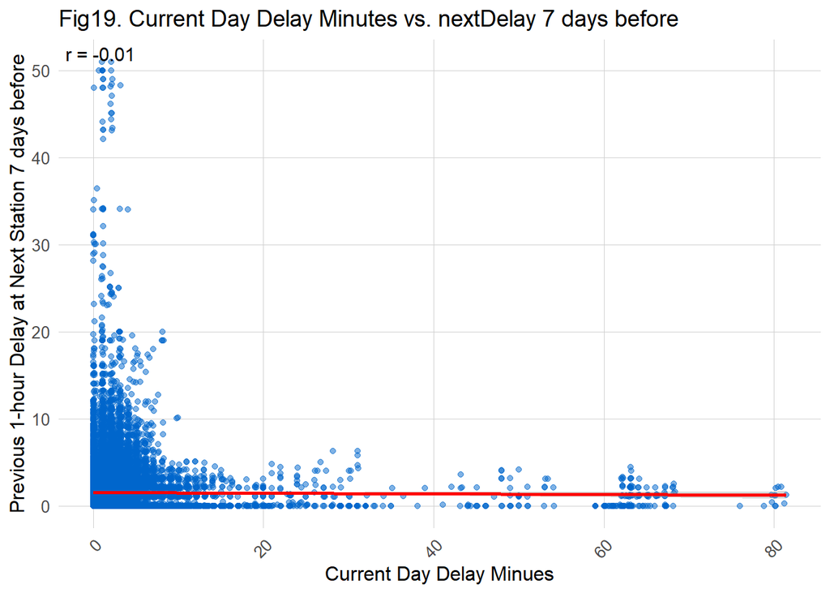

```r
sdnext <- as.data.frame(cor(dat_new$cd_delay_minutes, dat_new$sd_nextDelay))

ggplot(dat_new, aes(x=cd_delay_minutes, y=sd_nextDelay))+
  geom_point(color="#0066cc", alpha=0.5) +
  geom_smooth(method='lm', formula= y~x, color="red")+
  geom_text(data = sdnext, aes(label = paste("r =", round(sdnext, 2))),
            x=-Inf, y=Inf, vjust = 1.5, hjust = -.1, size=4) +
  labs(x = "Current Day Delay Minues",
       y = "Previous 1-hour Delay at Next Station 7 days before",
       title= "Fig19. Current Day Delay Minutes vs. nextDelay 7 days before") +
  plotTheme +
  theme(axis.title.x = element_text(size = 12),
        axis.title.y = element_text(size = 12),
        plot.title = element_text(size = 14))
```

Figure 19 shows the relationship between real-time delay minutes and the summarized previous 1-hour delay at next station at previous 7 days.  
Similarly to Figure 13, there is no clear linear correlations between them.

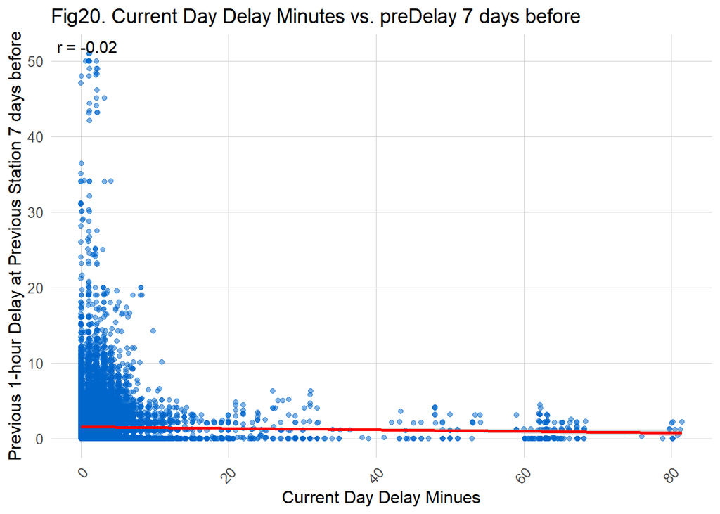

```r
sdpre <- as.data.frame(cor(dat_new$cd_delay_minutes, dat_new$sd_preDelay))

ggplot(dat_new, aes(x=cd_delay_minutes, y=sd_preDelay))+
  geom_point(color="#0066cc", alpha=0.5) +
  geom_smooth(method='lm', formula= y~x, color="red")+
  geom_text(data = sdpre, aes(label = paste("r =", round(sdpre, 2))),
            x=-Inf, y=Inf, vjust = 1.5, hjust = -.1, size=4) +
  labs(x = "Current Day Delay Minues",
       y = "Previous 1-hour Delay at Previous Station 7 days before",
       title= "Fig20. Current Day Delay Minutes vs. preDelay 7 days before") +
  plotTheme +
  theme(axis.title.x = element_text(size = 12),
        axis.title.y = element_text(size = 12),
        plot.title = element_text(size = 14))
```

Figure 20 shows the relationship between real-time delay minutes and the previous 1-hour delay at previous station at 7 days before. There is no clear linear relationship between them.  
Although the preDelay and nextDelay feature do not reflect clear linear relationship with the real delay minutes, we believe that if NJ Transit later want to adopt our model for their entire system, the preDelay and nextDelay features will be more influential because it will consider the delay of trains on other lines sharing the same station.

### 5. Model

#### 5.1 Split Test/Train Dataset

```r
train.set <- dat_new %>%
  filter(month == 3 | month == 4)

test.set <- dat_new %>%
  filter(month == 5)
```

We will use data from March 8 to April 30 to train our model and use data from May 1 to May 16 to validate the model.

#### 5.2 Regression

```r
reg <- lm(cd_delay_minutes ~ train_id + from + to  +
            cd_dotw2 + cd_potd + cd_avgSpeed + cd_cumulative_delay_5stopsAway +
            + cd_Wind_Drect +cd_Wind_Speed + cd_Gust + cd_Precipitation +
            cd_Visibility+ sd_delay_minutes + sd_cumulative_delay + sd_preDelay + sd_nextDelay,
          data = train.set)
```

Here are all the independent variables we used:

- Under current date
  - train id
  - departure station
  - arrival station
  - day of the week
  - period of the day
  - scheduled speed between the departure and arrival station
  - cumulative delay minutes from 5 stops away
  - wind direction
  - wind speed
  - gust
  - precipitation
  - visibility
- From 7 days ago
  - delay minutes of the same train at the same station
  - cumulative delay of the same train up to the station of prediction
  - total delay minutes at the previous station in the previous floor hour period
  - total delay minutes at the next station in the previous floor hour period

```r
stargazer(reg, type = "html",
          title = "Regression results",
          single.row = TRUE)
```

**Regression results**

|  | *Dependent variable:* |
| --- | --- |
|  | cd_delay_minutes |
| train_id1101 | -0.091 (0.359) |
| train_id1102 | -0.109 (0.300) |
| train_id1103 | -0.769** (0.302) |
| train_id1107 | 0.316 (0.320) |
| train_id1109 | 0.106 (0.357) |
| train_id1113 | 0.449 (0.339) |
| train_id1116 | 46.895*** (0.486) |
| train_id1118 | -2.583*** (0.336) |
| train_id1120 | -0.163 (0.362) |
| train_id1122 | -0.698* (0.362) |
| train_id1124 | -1.275*** (0.362) |
| train_id1125 | -0.571 (0.372) |
| train_id1127 | 0.204 (0.365) |
| train_id1128 | -1.006*** (0.362) |
| train_id1129 | -0.849** (0.388) |
| train_id1130 | -0.844** (0.362) |
| train_id1132 | -0.736* (0.378) |
| train_id1133 | -0.612* (0.350) |
| train_id1134 | -0.387 (0.392) |
| train_id1163 | -0.127 (0.410) |
| train_id1204 | -0.511 (0.331) |
| train_id1205 | -0.813** (0.362) |
| train_id1206 | -0.936*** (0.342) |
| train_id1207 | -0.655* (0.358) |
| train_id1208 | -0.804** (0.342) |
| train_id1210 | 0.588* (0.342) |
| train_id1212 | -1.158*** (0.342) |
| train_id1213 | -1.250*** (0.363) |
| train_id1214 | -1.415*** (0.354) |

[output cut: 128 more lines]

The regression result shows that our model has R-squared of 0.81, and adjusted R-squared of 0.809. In other words, around 81% of the variation in the delay minutes can be explained by the model.

#### 4.3 Predicted vs. Observed

```r
prediction <- predict(reg, newdata = test.set)
prediction[prediction < 1/60] <- 0

test.set$pred <- prediction
test.set$err <- test.set$cd_delay_minutes - test.set$pred
test.set$absErr <- abs(test.set$err)
```

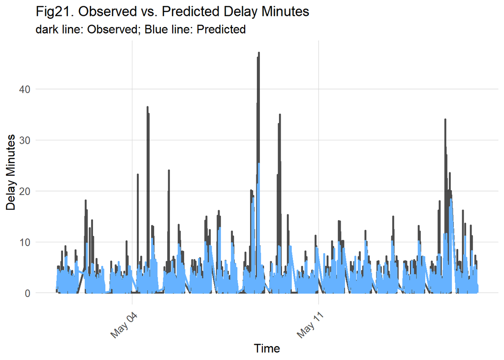

```r
test.set %>%
  mutate(scheduled_time = as_datetime(scheduled_time, tz = "America/New_York")) %>%
  mutate(interval60 = floor_date(ymd_hms(scheduled_time), unit = hours(x = 1))) %>%
  ggplot() +
  geom_line(aes(x = interval60, y = cd_delay_minutes), alpha=0.7, size=0.9) +
  geom_line(aes(x = interval60, y = pred), color="#66B2FF", size=0.9)+
  labs(title="Fig21. Observed vs. Predicted Delay Minutes",
       subtitle="dark line: Observed; Blue line: Predicted",
       x = "Time",
       y = "Delay Minutes")+
  plotTheme+
  theme(plot.title = element_text(size = 14),
        plot.subtitle = element_text(size=12),
        axis.title.x = element_text(size = 12),
        axis.title.y = element_text(size = 12))
```

Figure 21 shows the predicted delay minutes vs. the observed delay minutes from May 1 to May 16 this year. From the figure, we could see that our model works well on predicting short-time delays, but does not predict well on long-time delays.

#### 4.4 Mean Absolute Error

In order to evaluate the model, we calculate the mean absolute error (MAE).

```r
#Mean Absolute Error

test.set %>%
  mutate(delay = case_when(cd_delay_minutes <= 2 ~ "0-2 min",
                           cd_delay_minutes > 2 & cd_delay_minutes <=5 ~ "2-5 min",
                           cd_delay_minutes > 5 & cd_delay_minutes <= 10 ~ "5-10 min",
                           cd_delay_minutes > 10 & cd_delay_minutes <= 15 ~ "10-15 min",
                           cd_delay_minutes > 15 & cd_delay_minutes <= 20 ~ "15-20 min",
                           cd_delay_minutes > 20 & cd_delay_minutes <= 25 ~ "20-25 min",
                           cd_delay_minutes > 25 & cd_delay_minutes <= 30 ~ "25-30 min",
                           cd_delay_minutes > 30 ~ "over 30 min")) %>%
  group_by(delay) %>%
  summarise(MAE = mean(absErr)) %>%
  arrange(MAE) %>% knitr::kable(caption = "Table1. MAE for different time group") %>% kableExtra::kable_styling(bootstrap_options = c("striped", "hover", "condensed"))
```

Table1. MAE for different time group

| delay | MAE |
| --- | --- |
| 2-5 min | 0.8120474 |
| 0-2 min | 1.0056735 |
| 5-10 min | 2.4709874 |
| 10-15 min | 5.3777252 |
| 15-20 min | 9.6007797 |
| 20-25 min | 17.0053043 |
| 25-30 min | 17.6669591 |
| over 30 min | 30.5943559 |

We classify the delay minutes as eight groups and show the MAE for each group. From Table 1, we could see that our model works best on predicting 2-5 minutes delays. The MAE is less than 1, which is less than 1 minutes, which is very useful to help workers regulate passengers to keep social distancing. However, our model does not do well on predicting long-time delays, especially for delays which are longer than 20 minutes. We will further discuss this issue in the discussion section.

```r
#MAE for Secaucus Junction

test.set %>%
  filter(to == "Secaucus Lower Lvl") %>%
  mutate(delay = case_when(cd_delay_minutes <= 2 ~ "0-2 min",
                           cd_delay_minutes > 2 & cd_delay_minutes <=5 ~ "2-5 min",
                           cd_delay_minutes > 5 & cd_delay_minutes <= 10 ~ "5-10 min",
                           cd_delay_minutes > 10 & cd_delay_minutes <= 15 ~ "10-15 min",
                           cd_delay_minutes > 15 & cd_delay_minutes <= 20 ~ "15-20 min",
                           cd_delay_minutes > 20 & cd_delay_minutes <= 25 ~ "20-25 min",
                           cd_delay_minutes > 25 & cd_delay_minutes <= 30 ~ "25-30 min",
                           cd_delay_minutes > 30 ~ "over 30 min")) %>%
  group_by(delay) %>%
  summarise(MAE = mean(absErr)) %>%
  arrange(MAE) %>% knitr::kable(caption = "Table2. MAE for station Secaucus Junction") %>% kableExtra::kable_styling(bootstrap_options = c("striped", "hover", "condensed"))
```

Table2. MAE for station Secaucus Junction

| delay | MAE |
| --- | --- |
| 2-5 min | 0.9834032 |
| 0-2 min | 1.0210357 |
| 5-10 min | 2.6559640 |
| 15-20 min | 5.9928446 |
| 10-15 min | 6.2049541 |
| 20-25 min | 22.5700771 |
| over 30 min | 26.8764688 |

In order to further analyze MAE, we pick a major transferring station from the line, [Secaucus Junction](https://en.wikipedia.org/wiki/Secaucus_Junction).  
From Table 2, we could see that the MAE is very close the that of Table 1. Especially for 2-5 minutes group, which has MAE less than 1.

```r
test.set %>%
  filter(to == "Salisbury Mills-Cornwall") %>%
  mutate(delay = case_when(cd_delay_minutes <= 2 ~ "0-2 min",
                           cd_delay_minutes > 2 & cd_delay_minutes <=5 ~ "2-5 min",
                           cd_delay_minutes > 5 & cd_delay_minutes <= 10 ~ "5-10 min",
                           cd_delay_minutes > 10 & cd_delay_minutes <= 15 ~ "10-15 min",
                           cd_delay_minutes > 15 & cd_delay_minutes <= 20 ~ "15-20 min",
                           cd_delay_minutes > 20 & cd_delay_minutes <= 25 ~ "20-25 min",
                           cd_delay_minutes > 25 & cd_delay_minutes <= 30 ~ "25-30 min",
                           cd_delay_minutes > 30 ~ "over 30 min")) %>%
  group_by(delay) %>%
  summarise(MAE = mean(absErr)) %>%
  arrange(MAE) %>% knitr::kable(caption = "Table3. MAE for station Salisbury Mills-Cornwall") %>% kableExtra::kable_styling(bootstrap_options = c("striped", "hover", "condensed"))
```

Table3. MAE for station Salisbury Mills-Cornwall

| delay | MAE |
| --- | --- |
| 2-5 min | 1.336027 |
| 5-10 min | 1.763594 |
| 0-2 min | 1.815305 |
| 10-15 min | 4.437918 |
| 15-20 min | 14.243150 |
| 20-25 min | 20.333382 |
| over 30 min | 21.937017 |

```r
#MAE for Suffern

test.set %>%
  filter(to == "Suffern") %>%
  mutate(delay = case_when(cd_delay_minutes <= 2 ~ "0-2 min",
                           cd_delay_minutes > 2 & cd_delay_minutes <=5 ~ "2-5 min",
                           cd_delay_minutes > 5 & cd_delay_minutes <= 10 ~ "5-10 min",
                           cd_delay_minutes > 10 & cd_delay_minutes <= 15 ~ "10-15 min",
                           cd_delay_minutes > 15 & cd_delay_minutes <= 20 ~ "15-20 min",
                           cd_delay_minutes > 20 & cd_delay_minutes <= 25 ~ "20-25 min",
                           cd_delay_minutes > 25 & cd_delay_minutes <= 30 ~ "25-30 min",
                           cd_delay_minutes > 30 ~ "over 30 min")) %>%
  group_by(delay) %>%
  summarise(MAE = mean(absErr)) %>%
  arrange(MAE) %>% knitr::kable(caption = "Table4. MAE for station Suffern") %>% kableExtra::kable_styling(bootstrap_options = c("striped", "hover", "condensed"))
```

Table4. MAE for station Suffern

| delay | MAE |
| --- | --- |
| 0-2 min | 0.4917542 |
| 2-5 min | 0.9308075 |
| 5-10 min | 1.5132137 |
| 10-15 min | 5.2291265 |
| 15-20 min | 12.7904725 |
| 20-25 min | 18.6871730 |

Moreover, we make a table that shows the MAEs for different group for station Suffern. At previous part, we find out that station 144, which is Suffern, has the lowest mean delay minutes. The MAE for 2-5 minutes does not vary a lot, but the accuracy for 0-2 minutes group becomes much better. However, the model still does not work well on predicting long-time delays.

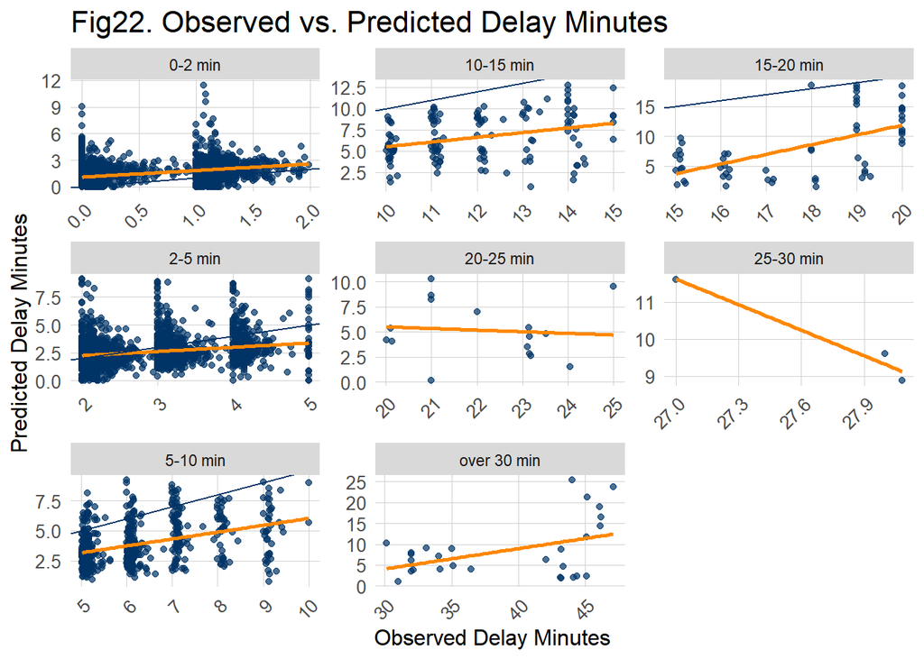

```r
#visualization
test.set %>%
  mutate(delay = case_when(cd_delay_minutes <= 2 ~ "0-2 min",
                           cd_delay_minutes > 2 & cd_delay_minutes <=5 ~ "2-5 min",
                           cd_delay_minutes > 5 & cd_delay_minutes <= 10 ~ "5-10 min",
                           cd_delay_minutes > 10 & cd_delay_minutes <= 15 ~ "10-15 min",
                           cd_delay_minutes > 15 & cd_delay_minutes <= 20 ~ "15-20 min",
                           cd_delay_minutes > 20 & cd_delay_minutes <= 25 ~ "20-25 min",
                           cd_delay_minutes > 25 & cd_delay_minutes <= 30 ~ "25-30 min",
                           cd_delay_minutes > 30 ~ "over 30 min")) %>%
  ggplot()+
  geom_point(aes(x= cd_delay_minutes, y = pred),color="#003366", alpha=0.7)+
  geom_smooth(aes(x= cd_delay_minutes, y= pred), method = "lm", se = FALSE, color = "#FF8800")+
  geom_abline(slope = 1, intercept = 0,color="#003366")+
  facet_wrap(~delay, scales = "free")+
  plotTheme+
  labs(title="Fig22. Observed vs. Predicted Delay Minutes",
       x = "Observed Delay Minutes",
       y = "Predicted Delay Minutes")+
  theme(plot.title = element_text(size = 16),
        axis.title.x = element_text(size = 12),
        axis.title.y = element_text(size = 12))
```

Figure 22 shows the relationship between observed delay minutes and the predicted delay minutes. Specifically, we over predicted the delays between 0 to 2 minutes, and under predicted the delays between 2 to 10 minutes. This is good for our use case, because by slightly counting more delays as around 2-5 minutes, station staffs will not miss potential crowding took place in the station.  
One reason for the higher accuracy for the 0-2 and 2-5 minutes groups is because we have much more training data from those two time groups. For time groups, especially 15-20 minutes, 20-25 minutes, 25-30 minutes and over 20 minutes, they have much fewer data. The lack of data might cause lower accuracy for those groups.

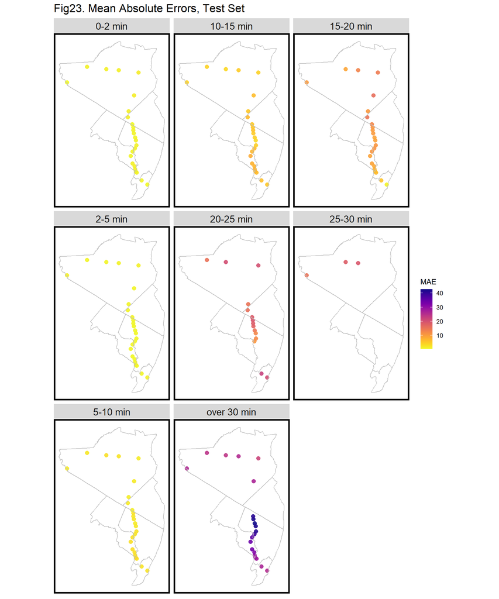

```r
acs5_84 <- acs5 %>%
  st_transform("EPSG:4326")

merge(test.set, stops, by="to") %>%
  mutate(delay = case_when(cd_delay_minutes <= 2 ~ "0-2 min",
                           cd_delay_minutes > 2 & cd_delay_minutes <=5 ~ "2-5 min",
                           cd_delay_minutes > 5 & cd_delay_minutes <= 10 ~ "5-10 min",
                           cd_delay_minutes > 10 & cd_delay_minutes <= 15 ~ "10-15 min",
                           cd_delay_minutes > 15 & cd_delay_minutes <= 20 ~ "15-20 min",
                           cd_delay_minutes > 20 & cd_delay_minutes <= 25 ~ "20-25 min",
                           cd_delay_minutes > 25 & cd_delay_minutes <= 30 ~ "25-30 min",
                           cd_delay_minutes > 30 ~ "over 30 min")) %>%
  group_by(to, to_lon, to_lat, delay) %>%
  summarise(MAE = mean(absErr), na.rm = TRUE) %>%
  ggplot() +
  geom_point(aes(x = to_lon, y = to_lat, color = MAE),
             fill = "transparent", size = 2.5, alpha = 0.9)+
  scale_colour_viridis(direction = -1,
                       discrete = FALSE, option="plasma")+
  geom_sf(data = acs5_84, color = "grey", fill = "transparent")+
  facet_wrap(~delay, ncol=3)+
  labs(title="Fig23. Mean Absolute Errors, Test Set")+
  mapTheme()+
  theme(plot.title = element_text(size = 16))
```

Figure 23 shows how the MAEs vary among space from different time groups. There is no clear difference for MAEs over space for some time groups, such as 0-2 min, 2-5 min, 5-10 min, and 10-15 min. But the MAEs vary among space for longer delays, especially for group over 30 min.

#### 4.5 Cross Validation

```r
fitControl <- trainControl(method = "cv",
                           number = 100,
                           savePredictions = TRUE)


set.seed(1234)

reg_cv <- train(cd_delay_minutes ~ train_id + from + to  +
            cd_dotw2 + cd_potd + cd_avgSpeed + cd_cumulative_delay_5stopsAway +
            cd_Wind_Drect + cd_Wind_Speed + cd_Gust + cd_Precipitation + cd_Visibility
            + sd_delay_minutes + sd_cumulative_delay + sd_preDelay + sd_nextDelay,
          data = train.set,
          method = "lm",
          trControl = fitControl,
          na.action = na.pass)
```

**Cross Validation Regression Result**

| Call: |
| --- |
| lm(formula = .outcome ~ ., data = dat) |

Residuals:

| Min | 1Q | Median | 3Q | Max |
| --- | --- | --- | --- | --- |
| -27.506 | -1.018 | -0.269 | 0.604 | 46.317 |

| Coefficients | Estimate | Std. Error | t value | p-value |
| --- | --- | --- | --- | --- |
| (Intercept) | 0.817983047 | 0.338455954 | 2.417 | 0.015663 * |
| train_id1101 | -0.091356674 | 0.358888345 | -0.255 | 0.799069 |
| train_id1102 | -0.108592264 | 0.299799847 | -0.362 | 0.717193 |
| train_id1103 | -0.769381651 | 0.301946116 | -2.548 | 0.010837 * |
| train_id1107 | 0.315691546 | 0.319573213 | 0.988 | 0.323233 |
| train_id1109 | 0.105536845 | 0.357357092 | 0.295 | 0.767747 |
| train_id1113 | 0.449217732 | 0.339092481 | 1.325 | 0.185260 |
| train_id1116 | 46.895012056 | 0.485737701 | 96.544 | < 0.0000000000000002 *** |
| train_id1118 | -2.583358039 | 0.336377670 | -7.680 | 0.00000000000001642 *** |
| train_id1120 | -0.163286530 | 0.361888256 | -0.451 | 0.651844 |
| train_id1122 | -0.698369187 | 0.362254935 | -1.928 | 0.053885 . |
| train_id1124 | -1.275148366 | 0.362013334 | -3.522 | 0.000428 *** |
| train_id1125 | -0.570788894 | 0.371990284 | -1.534 | 0.124938 |
| train_id1127 | 0.204202724 | 0.364605311 | 0.560 | 0.575439 |
| train_id1128 | -1.006437681 | 0.362246434 | -2.778 | 0.005468 ** |
| train_id1129 | -0.849045083 | 0.387642875 | -2.190 | 0.028512 * |
| train_id1130 | -0.844187892 | 0.362080492 | -2.331 | 0.019734 * |
| train_id1132 | -0.735822235 | 0.377984792 | -1.947 | 0.051581 . |
| train_id1133 | -0.612393127 | 0.350308432 | -1.748 | 0.080448 . |
| train_id1134 | -0.386728927 | 0.392070458 | -0.986 | 0.323957 |
| train_id1163 | -0.126515588 | 0.410035081 | -0.309 | 0.757667 |
| train_id1204 | -0.510654093 | 0.331279018 | -1.541 | 0.123215 |
| train_id1205 | -0.812940087 | 0.362496932 | -2.243 | 0.024929 * |
| train_id1206 | -0.935982682 | 0.341729994 | -2.739 | 0.006167 ** |
| train_id1207 | -0.655108074 | 0.358274302 | -1.829 | 0.067483 . |
| train_id1208 | -0.804488942 | 0.342022443 | -2.352 | 0.018672 * |
| train_id1210 | 0.588015737 | 0.341790096 | 1.720 | 0.085371 . |
| train_id1212 | -1.158009258 | 0.342067983 | -3.385 | 0.000712 *** |
| train_id1213 | -1.250207703 | 0.362916175 | -3.445 | 0.000572 *** |
| train_id1214 | -1.415019008 | 0.354452452 | -3.992 | 0.00006564677916493 *** |

[output cut: 120 more lines]

Signif. codes: 0 ‘**’ 0.001 ’**’ 0.01 ’’ 0.05 ‘.’ 0.1 ’ ’ 1

Residual standard error: 2.414 on 28610 degrees of freedom

Multiple R-squared: 0.81, Adjusted R-squared: 0.809

F-statistic: 813.1 on 150 and 28610 DF, p-value: < 0.00000000000000022

```r
mean(test.set$absErr) %>%
  knitr::kable(caption = "Table5. Regression MAE", col.names = "MAE") %>%
  kableExtra::kable_styling(bootstrap_options = c("striped", "hover", "condensed"))
```

Table5. Regression MAE

| MAE |
| --- |
| 1.266233 |

```r
reg_cv$results$MAE %>%
  knitr::kable(caption = "Table6. Cross-Validation MAE", col.names = "MAE") %>%
  kableExtra::kable_styling(bootstrap_options = c("striped", "hover", "condensed"))
```

Table6. Cross-Validation MAE

| MAE |
| --- |
| 1.313133 |

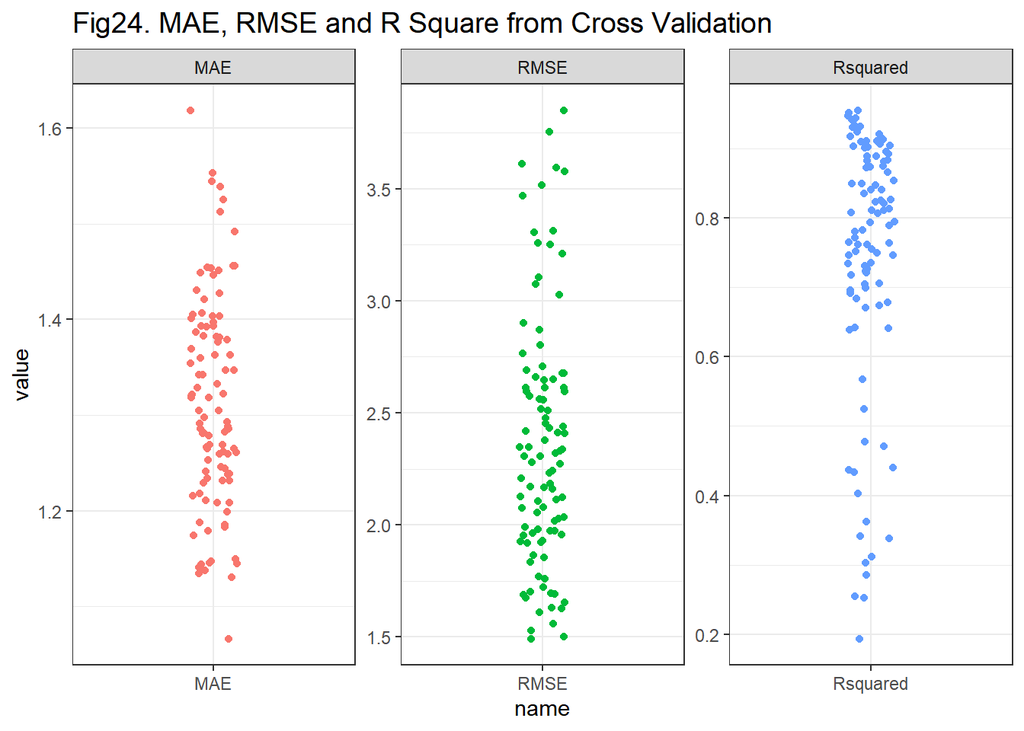

```r
# plot folds results
reg_cv$resample %>%
  pivot_longer(-Resample) %>%
  mutate(name = as.factor(name)) %>%
  ggplot(., aes(x = name, y = value, color = name)) +
  geom_jitter(width = 0.1) +
  facet_wrap(~name, ncol = 3, scales = "free") +
  labs(title = "Fig24. MAE, RMSE and R Square from Cross Validation") +
  theme_bw() +
  theme(
    legend.position = "none",
    plot.title = element_text(size = 14)
  )
```

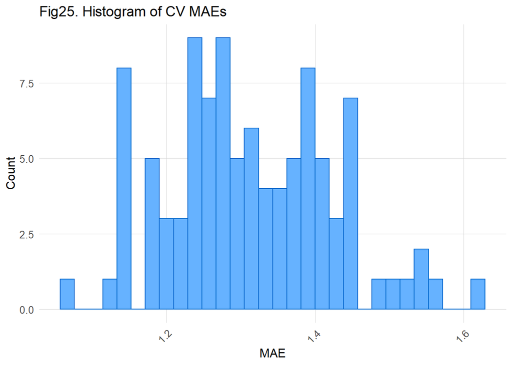

```r
# plot the MAE histogram
ggplot(as.data.frame(reg_cv$resample), aes(x=MAE)) +
  geom_histogram(color = "#0066CC", fill = "#66B2FF") +
  labs(title = "Fig25. Histogram of CV MAEs",
       x = "MAE",
       y = "Count") +
  plotTheme +
  theme(plot.title = element_text(size = 14),
        plot.subtitle = element_text(size=12),
        axis.title.x = element_text(size = 12),
        axis.title.y = element_text(size = 12))
```

We also performed a 100-fold cross validation using the training data of March and April in 2020. Table 6 shows the overall MAE of the cross validation result. Comparing to the overall MAE of 1.27 minutes derived by using the single test set as shown in Table 5, the cross validation MAE of 1.31 minutes is 0.04 minutes greater. The difference is less than 3 seconds. Therefore, we believe our model is generalizable throughout pandemic from March to May.

### 6. Discussion

Under normal circumstances, it is not meaningful to predict a 3-minute delay of a train. Even if an accurate model can tell the passengers to expect a 3-minutes delay, one can imagine the passengers’ attitude will be like “So what?” Under the pandemic, ironically, predicting a 3-mintute train delay matters because most people think such delay does not matter. Passengers will not show up late on a platform or at a station because of a 3-minute delay, so the crowds waiting for the delayed trains can discourage social distancing from happening. Such behavior can be extremely dangerous for spreading the virus among passengers. We believe train service providers, such as New Jersey Transit, should be responsible for keeping their passengers safer as they can provide guidance for social distancing and regulate the passenger circulation in stations. Our model is built for them to prepare ahead of time.  
The latest input data for our predictive model is the cumulative delay of the target train from 5 stops away on the day of prediction. We believe such design saves enough time for station staff to prepare their plans. Other input data can also be easily obtained from data generated seven days ago or from the local weather forecast services. We only used NYC weather data at present due to free data sources availability online, but we believe NJ Transit should have the resources to get more local weather data and improve the model.  
In terms of the accuracy of our model, only calculating the overall MAE could be meaningless for our use case. Therefore, by looking at the MAE categorized by the test’s true delay time, we found the MAE for predicting the 2 to 5 minutes delay is less than 1 minute. This means our model should be accurate enough to tell the staffs whether they need to prepare for the congestion of crowds. As we found in Figure 22, we overly estimated the delays between 0 and 2 minutes, while under estimated the delays between 5 and 10 minutes. That means our prediction categorized more circumstances into the 2 to 5 minutes scenario in which guidance should be prepared. In that way, we can be more confident not to miss any potential crowding happened due to short time delays.  
Although our model showed drawbacks when predicting for longer delays, we do not think those will affect the general use case of this model. In fact, longer delays are not usually caused by time-space factors we examined in this project. According to the publicized official reasons of delays on Twitter (@ NJTRANSIT_MBPJ), long time delays are usually caused by things like mechanical problem, maintenance, or even police activities. Therefore, to get more accurate prediction for longer delays, NJ Transit should add those factors into consideration, if they decide to adopt our model.  
Lastly, the data we used from Kaggle was neither official, nor completed. If NJ Transit is interest in using our model, they should use their official data collected from the train operations. We also believe that if they can expand the model to fit the entire system, the model should be even more accurate. This is because for the network delays engineered in our dataset, we could only get data on the Main-Bergen County Line that we focused on. However, for large stations, several lines will share the tracks and platforms, the network delays will be more accurate when all the lines are taken into account. In this way, the delays of train in and out larger transferring stations can explain more about the delay behavior happening in the system. Thus, if NJ Transit use this model in the future, they can provide more comprehensive data so that model will become usable.

### 7. Conclusion

In conclusion, the OLS model we developed for predicting short time train delays will be useful for helping station staffs prepare guidance for crowd congestions. It predicts well on short-time delays, in turn reach our goal to help transit workers organize customers to keep social distance. We will also encourage NJ Transit to add more data and variables of their train and track condition which are highly relevant to train delays. With the motivation to keep passenger safe and healthy, we recommend the New Jersey Transit to use our model as the second wave of COVID-19 pandemic hitting the US.

#### Reference

Data:

[Kaggle](https://www.kaggle.com/pranavbadami/nj-transit-amtrak-nec-performance)

[NJGIN Open Data](https://njogis-newjersey.opendata.arcgis.com/datasets/railroad-stations-in-nj)

US Census

Weather Data from the Iowa Environment Mesonet (riem package in R)

Others:

Symptoms of Coronavirus, [CDC](https://www.cdc.gov/coronavirus/2019-ncov/symptoms-testing/symptoms.html).

Coronavirus disease (COVID-19) advice for the public, [WHO](https://www.who.int/emergencies/diseases/novel-coronavirus-2019/advice-for-public).

Service resumes at Penn Station after extensive delays on NJ Transit, Amtrak, Natasha D. Smith, [WPIX](https://www.pix11.com/news/local-news/manhattan/nearly-3-hour-delays-massive-crowds-continue-at-penn-station).

COVID-19, New Jersey, Google News.

MBPJ Train #1116, last alerts, [njtranshit.com](https://njtranshit.com/train/1116).